# Tidy Tuesday 06-04: Ramen

https://github.com/rfordatascience/tidytuesday/tree/master/data/2019/2019-06-04

```r
library(tidyverse)
library(tidytext)
ramen_ratings <- readr::read_csv("https://raw.githubusercontent.com/rfordatascience/tidytuesday/master/data/2019/2019-06-04/ramen_ratings.csv")
colnames(ramen_ratings)
```

```
[1] "review_number" "brand"         "variety"       "style"         "country"       "stars"
```

First, I used head() and summary() to get a quick sense of what this data looks like:

```r
head(ramen_ratings)
```

| review_number | brand | variety | style | country | stars |
| --- | --- | --- | --- | --- | --- |
| 3180 | Yum Yum | Tem Tem Tom Yum Moo Deng | Cup | Thailand | 3.75 |
| 3179 | Nagatanien | tom Yum Kung Rice Vermicelli | Pack | Japan | 2.00 |
| 3178 | Acecook | Kelp Broth Shio Ramen | Cup | Japan | 2.50 |
| 3177 | Maison de Coree | Ramen Gout Coco Poulet | Cup | France | 3.75 |
| 3176 | Maruchan | Gotsumori Shio Yakisoba | Tray | Japan | 5.00 |
| 3175 | Myojo | Chukazanmai Tantanmen | Cup | Japan | 3.50 |

```r
summary(ramen_ratings)
```

```
 review_number       brand             variety             style             country              stars
 Min.   :   1.0   Length:3180        Length:3180        Length:3180        Length:3180        Min.   :0.000
 1st Qu.: 795.5   Class :character   Class :character   Class :character   Class :character   1st Qu.:3.250
 Median :1590.0   Mode  :character   Mode  :character   Mode  :character   Mode  :character   Median :3.750
 Mean   :1590.1                                                                               Mean   :3.688
 3rd Qu.:2384.5                                                                               3rd Qu.:4.500
 Max.   :3180.0                                                                               Max.   :5.000
 NA's   :1                                                                                    NA's   :14
```

The first question that jumped out at me: how do the median ratings (and distribution of ratings) differ between countries? What is best and worst country for ramen? A horizontal box plot seems like a good way to get started:

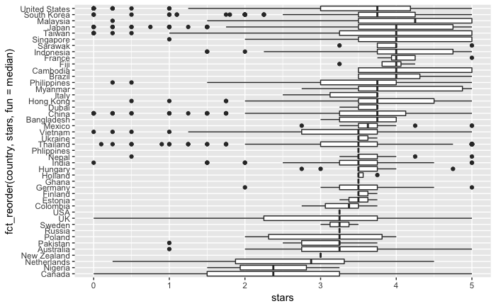

```r
ramen_ratings %>%
  ggplot(aes(x=fct_reorder(country, stars, fun=median), y=stars)) +
    geom_boxplot() +
    coord_flip()
```

Here I noticed some strange behaviors – in particular, take a look at the highest-ranked countries. It appears that United States is both first-ranked and, somehow, has a lower median rating than Japan! How is that? After poking around, I realized that the “fun=median” parameter passed into ggplot2’s did not identify outliers, whereas ggplot2’s boxplot geom identifies outliers and generates the 25th-50th-75th percentile box excluding those outliers. How could we get “fun=median” to behave similarly?

For the time being, I proceeded to visualizing by style (and noticed the same median ranking issue yet again!)

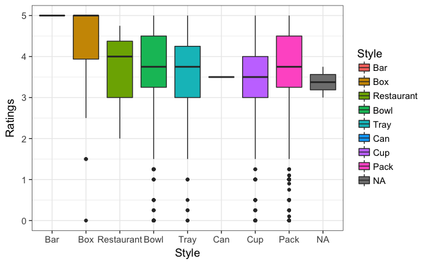

```r
ramen_ratings %>%
  ggplot(aes(x = fct_reorder(style, stars, fun=median, .desc=TRUE), y=stars)) +
        geom_boxplot(aes(fill = fct_reorder(style, stars, fun=median, .desc=TRUE))) +
        # geom_jitter(position=position_jitter(0.2)) +
        theme_bw(base_size = 14) +
        xlab("Style") +
        ylab("Ratings") +
        scale_fill_discrete(guide = guide_legend(title = "Style"))
```

The lack of a box for Can made me realize, oh wait, is there only one observation with a Can style in our dataset? Can we do some simple low-pass filtering to get more focused data? Sure enough:

```r
ramen_ratings %>%
  group_by(style) %>%
  count()
```

| style | n |
| --- | --- |
| Bar | 1 |
| Bowl | 612 |
| Box | 32 |
| Can | 1 |
| Cup | 559 |
| Pack | 1832 |
| Restaurant | 3 |
| Tray | 138 |
| NA | 2 |

For simplicity’s sake, I decided to exclude Bar, Can, and Restaurant, as well as ramen with Null Style values. I wanted to compare these newly simplified distributions, and sure enough, take a look at the disparity between Box and Cup ramen!:

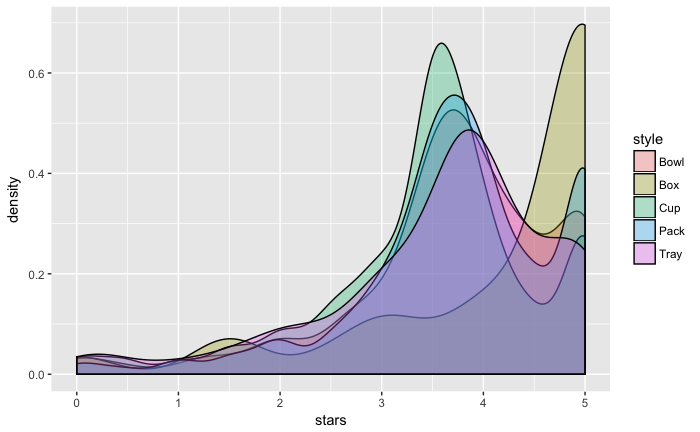

```r
ramen_cleaner <- ramen_ratings %>%
  filter(style != "NA" & style != "Bar" & style != "Can" & style != "Restaurant")


ramen_cleaner %>%
  ggplot(aes(x = stars, fill=style)) +
        geom_density(alpha=0.3)
```

Now let’s redo box plots excluding low-count styles:

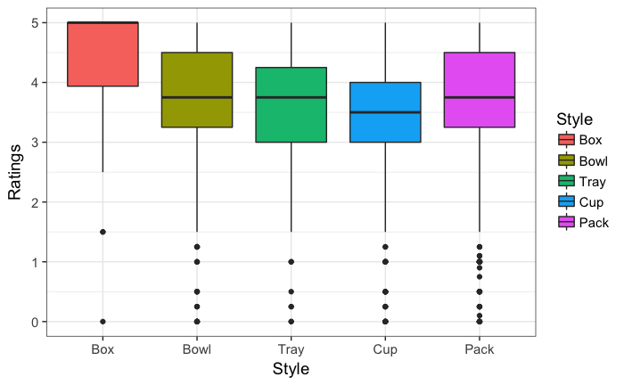

```r
ramen_cleaner %>%
  ggplot(aes(x = fct_reorder(style, stars, fun=median, .desc=TRUE), y=stars)) +
        geom_boxplot(aes(fill = fct_reorder(style, stars, fun=median, .desc=TRUE))) +
        # geom_jitter(position=position_jitter(0.2)) +
        theme_bw(base_size = 14) +
        xlab("Style") +
        ylab("Ratings") +
        scale_fill_discrete(guide = guide_legend(title = "Style"))
```

```r
NA
```

## Part Two: Text Analysis

```r
all_words_in_variety <- ramen_ratings %>%
  unnest_tokens(word, variety) %>%
  select(word)

words_sorted <- all_words_in_variety %>%
  group_by(word) %>%
  count() %>%
  arrange(desc(n))

words_sorted
```

| word | n |
| --- | --- |
| noodles | 797 |
| noodle | 660 |
| instant | 511 |
| ramen | 492 |
| flavour | 459 |
| flavor | 407 |
| chicken | 378 |
| spicy | 351 |
| beef | 276 |
| soup | 260 |

[output cut: 990 more lines]

```r
NA
```

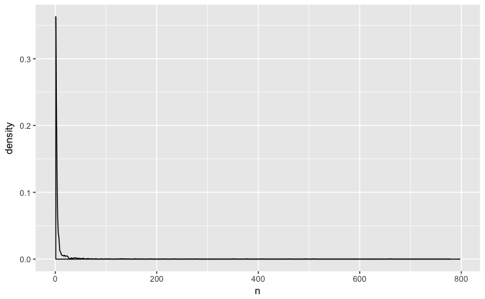

```r
words_sorted %>%
  ggplot(aes(x=n)) +
  geom_density()
```

```r
ramen_ratings <- ramen_ratings %>%
  mutate(variety = tolower(variety)) %>%
  mutate(meat = case_when(
    grepl("chicken", variety) ~ "chicken",
    grepl("beef", variety) ~ "beef",
    grepl("pork", variety) ~ "pork",
    grepl("shrimp", variety) ~ "shrimp",
    grepl("seafood", variety) ~ "seafood"))

ramen_ratings %>%
  group_by(meat) %>%
  count()
```

| meat | n |
| --- | --- |
| beef | 274 |
| chicken | 377 |
| pork | 127 |
| seafood | 128 |
| shrimp | 140 |
| NA | 2134 |

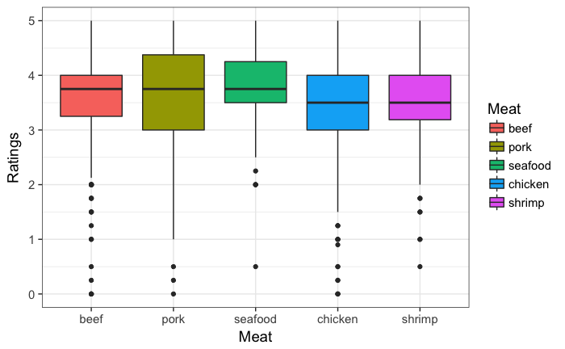

```r
ramen_ratings %>%
  filter(!is.na(meat)) %>%
  ggplot(aes(x = fct_reorder(meat, stars, fun=median, .desc=TRUE), y=stars)) +
        geom_boxplot(aes(fill = fct_reorder(meat, stars, fun=median, .desc=TRUE))) +
        # geom_jitter(position=position_jitter(0.2)) +
        theme_bw(base_size = 14) +
        xlab("Meat") +
        ylab("Ratings") +
        scale_fill_discrete(guide = guide_legend(title = "Meat"))
```

I waas actually quite surprised by the similarity across meat types! Perhaps the biggest difference is that pork has the widest interquartile range – which suggests that pork is the riskiest bet when picking up some random ramen! Sure enough:

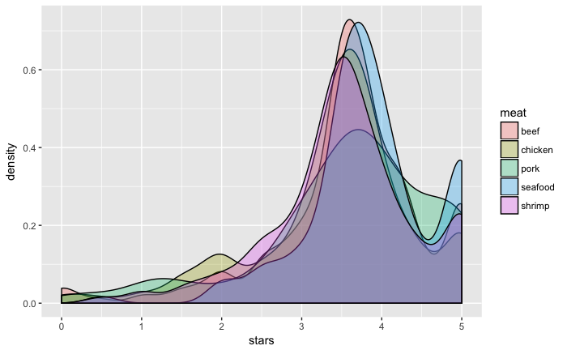

```r
ramen_ratings %>%
  filter(!is.na(meat)) %>%
  ggplot(aes(x = stars, fill=meat)) +
        geom_density(alpha=0.3)
```

I repeated the process for “spicy”, which I generated as a boolean variable based on the same substring grepl() search method:

```r
ramen_ratings <- ramen_ratings %>%
  mutate(variety = tolower(variety)) %>%
  mutate(is_spicy = grepl("spicy", variety))
```

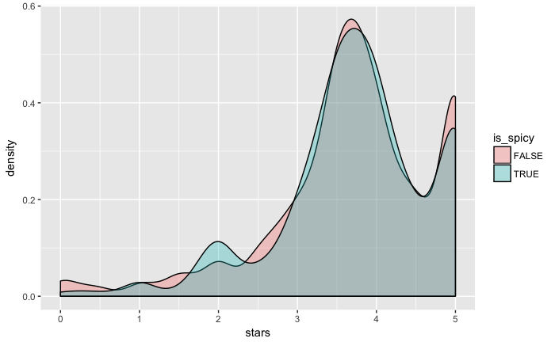

```r
ramen_ratings %>%
  ggplot(aes(x = stars, fill=is_spicy)) +
        geom_density(alpha=0.3)
```

Really not much of a difference! As my last technique, I repeated this approach for curry:

```r
ramen_ratings <- ramen_ratings %>%
  mutate(variety = tolower(variety)) %>%
  mutate(is_curry = grepl("curry", variety))
```

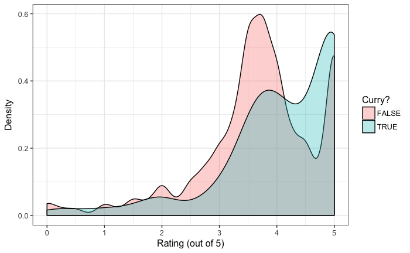

```r
ramen_ratings %>%
  ggplot(aes(x = stars, fill=is_curry)) +
        geom_density(alpha=0.3) +
        theme_bw(base_size = 12) +
        xlab("Rating (out of 5)") +
        ylab("Density") +
        scale_fill_discrete(guide = guide_legend(title = "Curry?"))
```

```r
ramen_ratings %>%
  group_by(is_spicy) %>%
  count()
```

| is_spicy | n |
| --- | --- |
| FALSE | 2835 |
| TRUE | 345 |